# FFx Houses

```r
options(width = 200)
library(httr)
library(jsonlite)
library(dplyr)
library(lubridate)
library(ggplot2)
library(corrplot)
library(RColorBrewer)
```

Define a function to call the data.gov API via GET request, that converts the JSON response to dataframe.

```r
get_data <- function(url) {
  request <- httr::GET(url = url)
  content <- content(request, as = 'text')
  flat <- fromJSON(content)
  df <- flat$features$properties
  print(nrow(df))
  return(df)
}
```

Use ‘get_data’ function to import all the housing data.

```r
start = Sys.time()
dwelling = get_data('https://opendata.arcgis.com/datasets/53ee1065351c4273ab91ba2e6cfbbc6d_2.geojson')
```

```
## [1] 333921
```

```r
sales = get_data('https://opendata.arcgis.com/datasets/764b1798c0434003a862e2734ba2b705_1.geojson')
```

```
## [1] 1249678
```

```r
values = get_data('https://opendata.arcgis.com/datasets/63b4c91c3a16425fb5ef9118dbce39ba_2.geojson')
```

```
## [1] 363384
```

```r
legal = get_data('https://opendata.arcgis.com/datasets/0c3415baff124473832c0e821c0a4ddc_1.geojson')
```

```
## [1] 363722
```

```r
land = get_data('https://opendata.arcgis.com/datasets/f1f0f31844cf49489134f9fa2b8f16f5_3.geojson')
```

```
## [1] 366281
```

```r
parcels = get_data('https://opendata.arcgis.com/datasets/7607cf5046c5495183251d1c9dba0014_1.geojson')
```

```
## [1] 364580
```

```r
owners = get_data('https://opendata.arcgis.com/datasets/753448c6e45c434d97b61e77ea752079_2.geojson')
```

```
## [1] 363722
```

```r
print(Sys.time()-start)
```

```
## Time difference of 2.98425 mins
```

Find Assessed Value

```r
values = values[,c('PARID', 'APRLAND', 'APRBLDG', 'APRTOT')]
```

Find most recent sale price for each parcel.

```r
sales = sales[,c('PARID', 'SALEDT', 'PRICE')]
sales$SALEDT <- as.Date(sales$SALEDT, "%Y-%m-%d")
sales$PRICE <- as.numeric(sales$PRICE)
sales <- filter(sales, sales$PRICE != 0)

sales_latest <- sales %>%
  arrange(desc(SALEDT)) %>%
  group_by(PARID) %>%
  summarise('date'=max(SALEDT),'price'=first(PRICE))
```

Concatenate Address Columns for Legal and Owners to get Zipcode and city. Filter out properties that have owners who live elsewhere.

```r
legal <- legal[,c('PARID', 'ADRNO', 'ADRADD', 'ADRDIR', 'ADRSTR', 'ADRSUF', 'TAXDIST_DESC')]
legal[is.na(legal)] <-''
legal$address <-  paste(legal$ADRNO, legal$ADRADD, legal$ADRDIR, legal$ADRSTR, legal$ADRSUF, sep=' ')

owners <- owners[,c('PARID', 'ADRNO', 'ADRADD', 'ADRDIR', 'ADRSTR', 'ADRSUF','CITYNAME', 'STATECODE', 'ZIP1')]
owners[is.na(owners)] <-''
owners$address <-  paste(owners$ADRNO, owners$ADRADD, owners$ADRDIR, owners$ADRSTR, owners$ADRSUF, sep=' ')

address = dplyr::left_join(legal, owners[,c('PARID','address', 'ZIP1', 'CITYNAME')], by = 'PARID')
address <- filter(address, address$address.x == address$address.y)
address <- address[,c('PARID', 'CITYNAME', 'ZIP1', 'address.x','address.y')]
```

The data contains all types of properties (commercial, condo/apartment buildings, etc) so filter for only single family property tpes

```r
single_fam = filter(parcels, parcels$LUC_DESC == 'Single-family, Detached ')
single_fam_dwelling = filter(dwelling, dwelling$PARID %in% single_fam$PARID)
```

Combine All Features

```r
combined <- left_join(single_fam_dwelling, values, by = 'PARID') %>%
 left_join(., address, by = 'PARID') %>%
 left_join(., sales_latest, by = 'PARID')
```

Fill missing values for continuous dwelling variables

```r
cols <- c('SFLA','RMBED','FIXBATH','FIXHALF','RECROMAREA','BSMTCAR')
for (c in cols){
  combined[c][is.na(combined[c])] <- 0

}
combined <- filter(combined, !is.na(combined$APRBLDG) )
```

Find min and max to identify outliers

```r
combined$YrSold <- year(combined$date)
recent <- filter(combined, combined$YrSold %in% c(2017,2018,2019,2020))
print(paste("Min Price:", min(recent$price), "Max Price:", max(recent$price)))
```

```
## [1] "Min Price: 3 Max Price: 4.3e+07"
```

Filter out potential data quality issues (sale price of 3 dollars) and extremely expensive houses (set upper limit to $3M) Calculate ratio of Appraised Total (land + Building) to most recent sale price.

```r
recent = recent[(recent$price > 100000 & recent$price < 3000000),]
recent$ratio = recent$APRTOT/recent$price
```

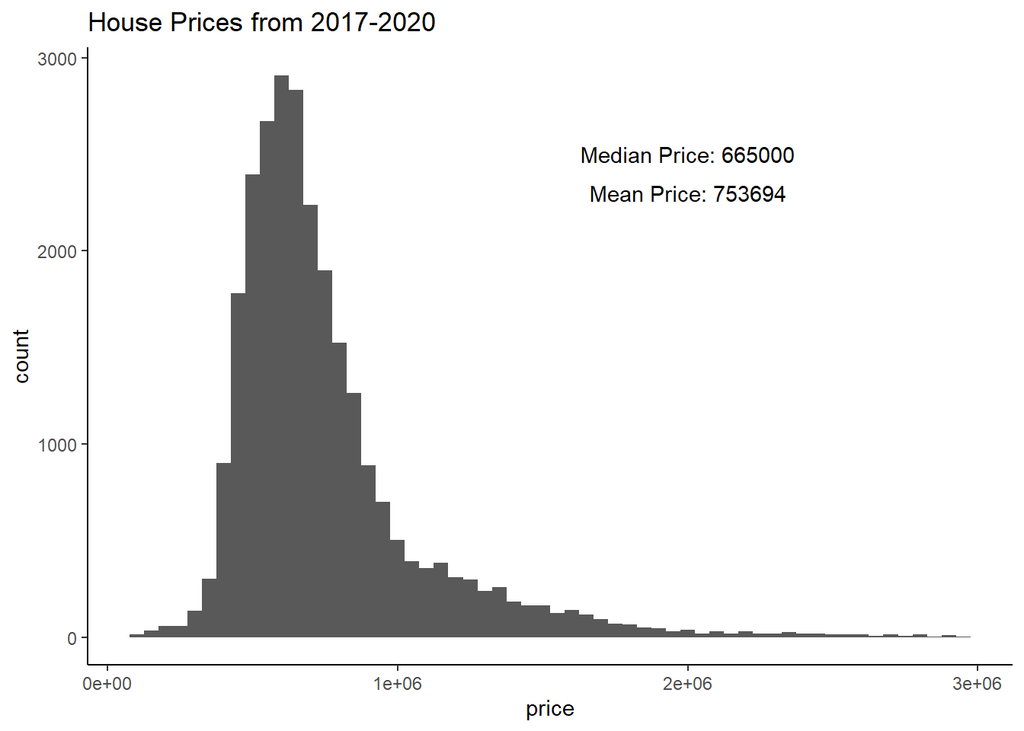

```r
h <- ggplot(data = recent, aes(x=price)) + geom_histogram(binwidth =5e4) + theme_classic() +ggtitle('House Prices from 2017-2020')
h +annotate(geom="text", x=2e6, y=2500, label=paste('Median Price:',median(recent$price)), color="black") +annotate(geom="text", x=2e6, y=2300, label=paste('Mean Price:',as.integer(mean(recent$price))), color="black")
```

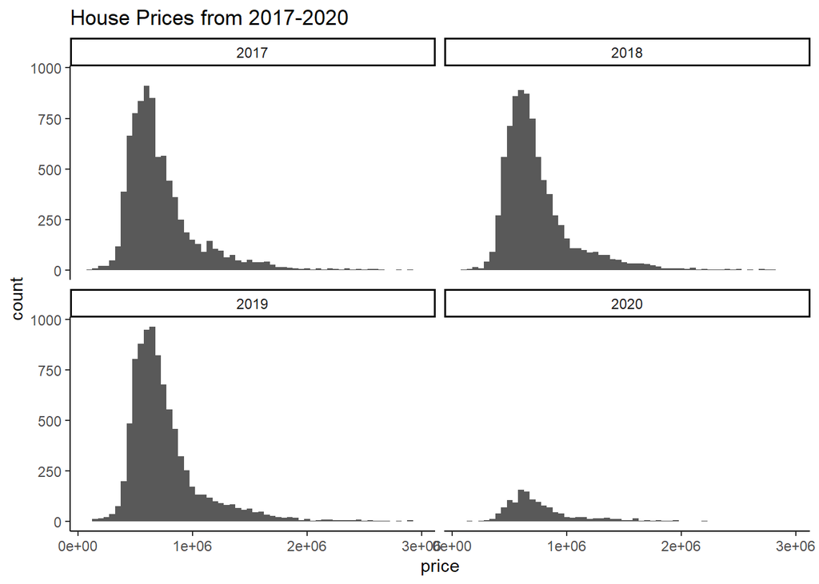

```r
h_facet = h + facet_wrap(~YrSold)
h_facet
```

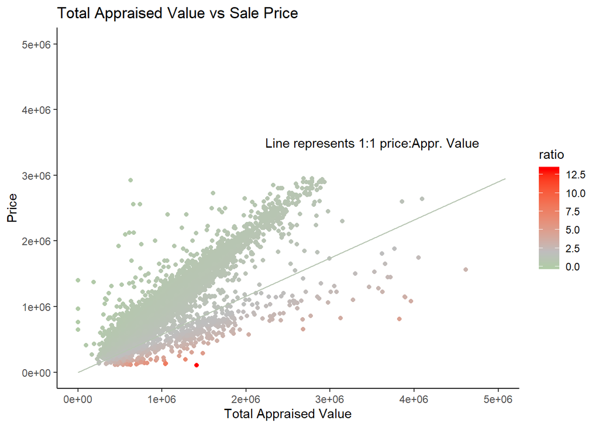

```r
apr <- ggplot(data = recent, aes(APRTOT, price, color = ratio)) + geom_point() + scale_y_continuous('Price',limits = c(0,5000000)) + scale_x_continuous('Total Appraised Value', limits = c(0,5000000)) + scale_color_gradient2(midpoint=2, low="green", mid = 'grey', high="red" ) + geom_segment(x = 0, y=0, yend = max(recent$price), xend = max(recent$APRTOT))+theme_classic()
apr + ggtitle('Total Appraised Value vs Sale Price') + annotate(geom = 'text', y = 3.5e6, x =3.5e6, label = "Line represents 1:1 price:Appr. Value" )
```

```r
houses <- recent[recent$ratio < 1.5,]
```

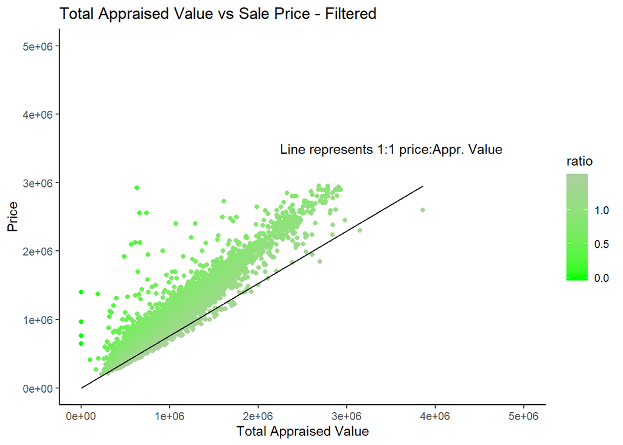

```r
apr <- ggplot(data = houses, aes(APRTOT, price, color = ratio)) + geom_point() + scale_y_continuous('Price',limits = c(0,5000000)) + scale_x_continuous('Total Appraised Value', limits = c(0,5000000)) + scale_color_gradient2(midpoint=2, low="green", mid = 'grey', high="red" ) + geom_segment(x = 0, y=0, yend = max(houses$price), xend = max(houses$APRTOT), color = "black")+theme_classic() + annotate(geom = 'text', y = 3.5e6, x =3.5e6, label = "Line represents 1:1 price:Appr. Value" )
apr + ggtitle('Total Appraised Value vs Sale Price - Filtered')
```

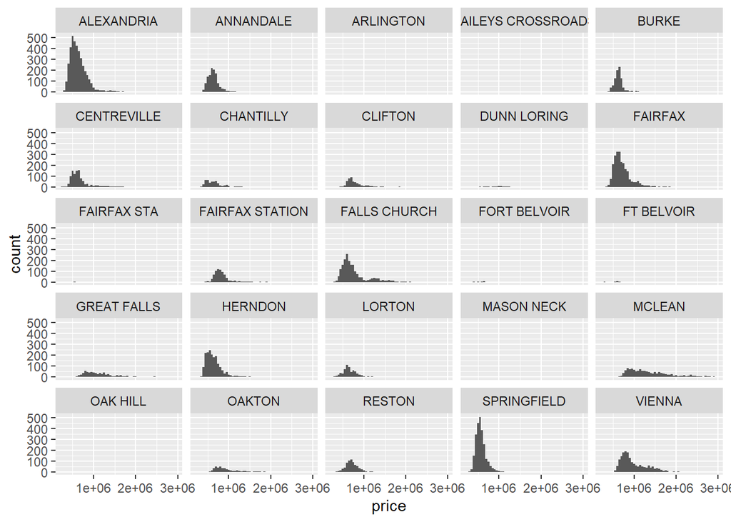

```r
houses <- filter(houses, (!is.na(houses$CITYNAME) & houses$CITYNAME != ''))

ggplot(houses, aes(x=price)) + geom_histogram(binwidth = 5e4) +facet_wrap(~CITYNAME)
```

There were some inconsistent city names and cities that had very few observations. I grouped based geography and corrected where the same city had differentn names in the data.

```r
houses <- mutate( houses, CityNew =
                    case_when (CITYNAME %in% c('BURKE','FAIRFAX STA','FAIRFAX STATION') ~ 'FAIRFAX',
                               CITYNAME %in% c('FORT BELVOIR','FT BELVOIR','LORTON', 'MASON NECK') ~ 'SPRINGFIELD',
                               CITYNAME %in% c('OAKTON','DUNN LORING') ~ 'VIENNA',
                               CITYNAME %in% c('OAK HILL', 'CENTREVILLE', 'CLIFTON') ~ 'CHANTILLY',
                               CITYNAME %in% c('HERNDON') ~ 'RESTON',
                               CITYNAME %in% c('GREAT FALLS') ~ 'MCLEAN',
                               CITYNAME %in% c('BAILEYS CROSSROADS', 'ARLINGTON') ~ 'ALEXANDRIA',
                               TRUE ~ CITYNAME))
```

Now down to 9 cities, each with at least a few hundred rows.

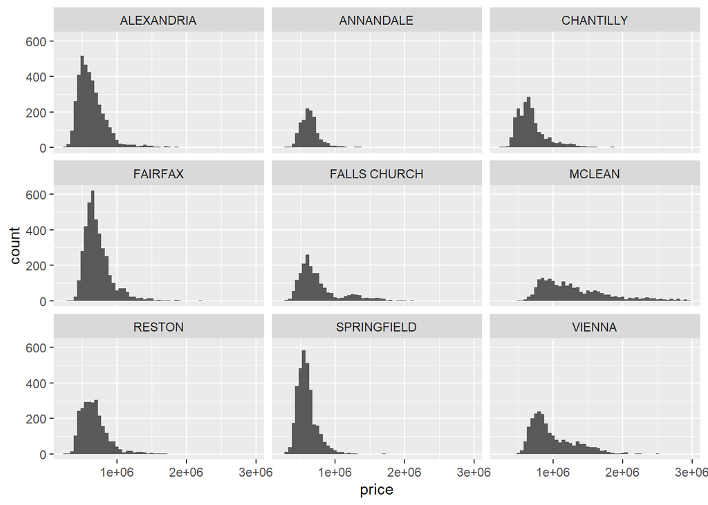

```r
ggplot(houses, aes(x=price)) + geom_histogram(binwidth = 5e4) +facet_wrap(~CityNew)
```

Find median home price sale price per year for each city

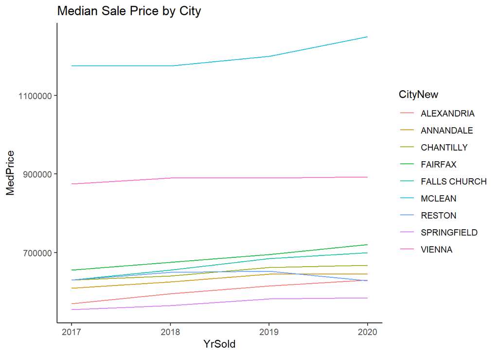

```r
medians <- houses %>%
  group_by(CityNew, YrSold) %>%
  summarise('MedPrice' = median(price))

ggplot(medians, aes(x=YrSold, y = MedPrice, color = CityNew)) + geom_line(aes(linestyle = CityNew)) + theme_classic() + ggtitle('Median Sale Price by City')
```

Check One way anova for dwelling variables and City

```r
anv <- aov(price ~ SFLA+FIXBATH+RMBED+RECROMAREA+CityNew, data = houses)
summary(anv)
```

```
##                Df    Sum Sq   Mean Sq  F value Pr(>F)
## SFLA            1 1.644e+15 1.644e+15 74874.23 <2e-16 ***
## FIXBATH         1 8.473e+13 8.473e+13  3858.19 <2e-16 ***
## RMBED           1 1.880e+12 1.880e+12    85.59 <2e-16 ***
## RECROMAREA      1 1.604e+13 1.604e+13   730.40 <2e-16 ***
## CityNew         8 3.126e+14 3.907e+13  1779.06 <2e-16 ***
## Residuals   23289 5.115e+14 2.196e+10
## ---
## Signif. codes:  0 '***' 0.001 '**' 0.01 '*' 0.05 '.' 0.1 ' ' 1
```

View Correlations for both Price and Appraised Value. Not Supprising, the correlations are about identical.

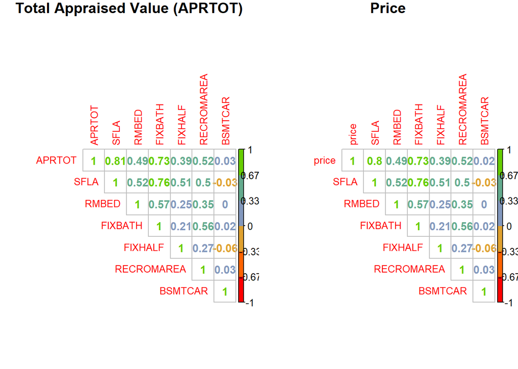

```r
col1 <- colorRampPalette(c('red', 'orange', 'cornflowerblue', 'chartreuse3'))

corrs <- cor(houses[,c('APRTOT', 'SFLA','RMBED','FIXBATH','FIXHALF','RECROMAREA','BSMTCAR')])
corrs1 <- cor(houses[,c('price', 'SFLA','RMBED','FIXBATH','FIXHALF','RECROMAREA','BSMTCAR')])

par(mfrow =c(1,2))
corrplot(corrs, type = 'upper', method = 'number', tl.cex = .8, number.cex = .9, col = col1(6), title = 'Total Appraised Value (APRTOT)',mar=c(0,0,1,0))
corrplot(corrs1, type = 'upper', method = 'number',tl.cex = .8, number.cex = .9,col = col1(6),title = 'Price',mar=c(0,0,1,0))
```

Find how much SFLA influences price for all houses

```r
mod_all <- lm(APRTOT ~ SFLA+FIXBATH+RMBED+RECROMAREA+CityNew, data = houses)
coef_all_apr <- summary(mod_all)$coef[2]

mod_all1 <- lm(price ~ SFLA+FIXBATH+RMBED+RECROMAREA+CityNew, data = houses)
coef_all_price <- summary(mod_all1)$coef[2]
```

Multiple regressions for each city to see how sale price changes based on house size (measured by Sq Ft Living Area) across each city while holding other significant variables constant

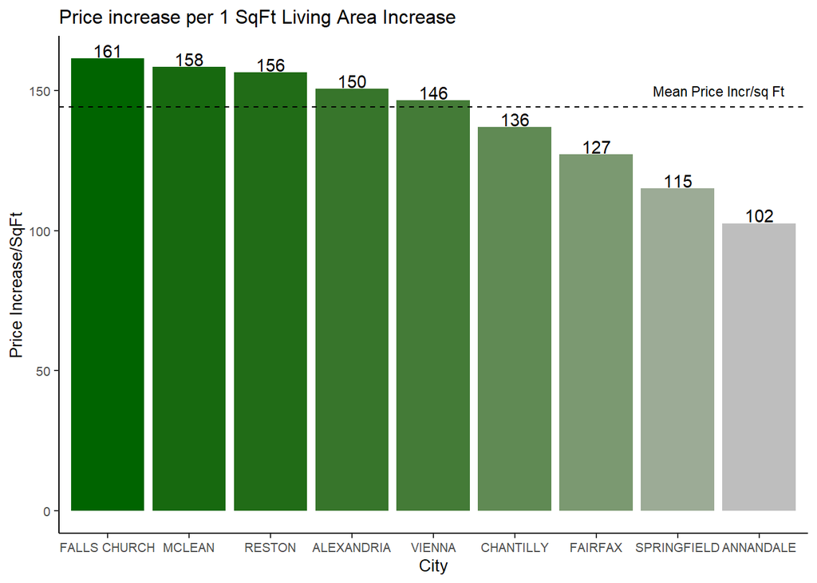

```r
cities <- unique(houses$CityNew)
sqftdf <- data.frame()
i = 1
for (city in cities){
  temp <- houses[houses$CityNew == city,]
  mod <- lm(price ~ SFLA+FIXBATH+RMBED+RECROMAREA, data = temp)
  sqftdf[i,1] <- as.character(city)
  sqftdf[i,2] <- summary(mod)$coef[2]
  i = i+1

}

ggplot(sqftdf, aes(x = reorder(V1,-V2), y = V2,fill = V2) ) + geom_bar(stat = "identity") + xlab('City') + ylab('Price Increase/SqFt') + ggtitle('Price increase per 1 SqFt Living Area Increase') + theme_classic() + theme(legend.position = "none") + geom_text(aes(label = as.integer(V2), vjust = -.1)) +  scale_fill_continuous(high = 'darkgreen', low = 'grey')+ geom_abline(intercept = coef_all_price, slope = 0, linetype = 'dashed') + annotate(geom = 'text', x = 8.5, y = 150, label = "Mean Price Incr/sq Ft", size = 3)+theme(text = element_text(size=10))
```

Multiple regressions for each city to see how Total Appraisal Value changes based on house size (measured by Sq Ft Living Area) across each city while holding other significant variables constant

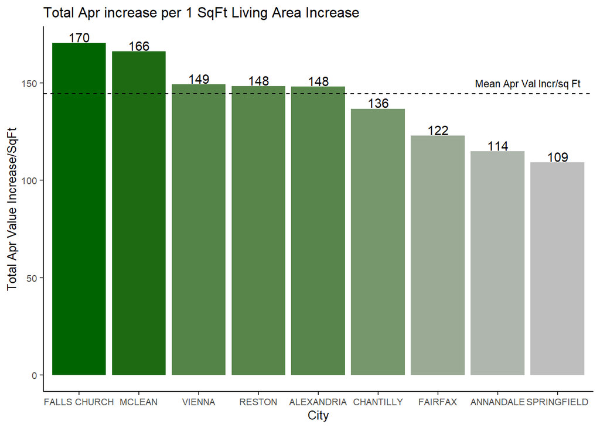

```r
sqftdf1 <- data.frame()
i = 1
for (city in cities){
  temp <- houses[houses$CityNew == city,]
  mod <- lm(APRTOT ~ SFLA+FIXBATH+RMBED+RECROMAREA, data = temp)
  sqftdf1[i,1] <- as.character(city)
  sqftdf1[i,2] <- summary(mod)$coef[2]
  i = i+1

}

ggplot(sqftdf1, aes(x = reorder(V1,-V2), y = V2,fill = V2) ) + geom_bar(stat = "identity") + xlab('City') + ylab('Total Apr Value Increase/SqFt') + ggtitle('Total Apr increase per 1 SqFt Living Area Increase') + theme_classic() + theme(legend.position = "none") + geom_text(aes(label = as.integer(V2), vjust = -.1)) +  scale_fill_continuous(high = 'darkgreen', low = 'grey')+ geom_abline(intercept = coef_all_apr, slope = 0, linetype = 'dashed') + annotate(geom = 'text', x = 8.5, y = 150, label = "Mean Apr Val Incr/sq Ft", size = 3) +theme(text = element_text(size=10))
```